# Lab 9

Heather Siart

11/17/2021

# Brown Creeper Chi-square

```r
require("here")
birds   = read.csv(here("data", "bird.sta.csv"))
hab     = read.csv(here("data", "hab.sta.csv"))
birdhab = merge(birds, hab, by=c("basin", "sub", "sta"))
table(birdhab$s.edge, birdhab$BRCR > 0)
```

```
##
##     FALSE TRUE
##   E   144   29
##   I   559  314
```

```r
br_creeper_table = table(birdhab$s.edge, birdhab$BRCR > 0)[, 2:1]
chisq.test(br_creeper_table)
```

```
##
##  Pearson's Chi-squared test with Yates' continuity correction
##
## data:  br_creeper_table
## X-squared = 23.3, df = 1, p-value = 1.386e-06
```

# Q1: State the null hypothesis of the Chi-square test.

Null hypothesis - brown creepers do not show a significance of presence or absence when comparing the edge or interior of their habitat.

# Q2: Consider the results of your test and explain whether you think that Brown Creepers show a significant habitat preference.

Based off the chi-square test brown creepers do show a significant difference in habitat preference. I can reject the null hypothesis.

# Q3: Show the R-code you can use to create a model fit (call it fit_species) of penguin body mass as predicted by penguin species.

```r
require(palmerpenguins)
fit_fl_sp =
  lm(
    formula = flipper_length_mm ~ species,
    data = penguins)
```

```r
fit_species =
  lm(
    formula = penguins$body_mass_g ~ penguins$species)
```

# Q4:Show the R-code you can use to create a model fit (call it fit_sex) of penguin body mass as predicted by sex.

```r
fit_sex =
  lm(
    formula = penguins$body_mass_g ~ penguins$sex)
```

# Q5: Show the R-code you can use to create a model fit (call it fit_both) of penguin body mass as predicted by species and sex.

```r
fit_both =
  lm(
    formula = penguins$body_mass_g ~ penguins$species * penguins$sex)
```

# Q6: Include a conditional boxplot corresponding to your fit_species model

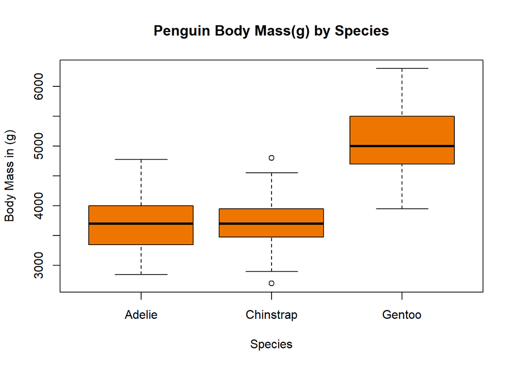

```r
boxplot(formula(fit_species),
        main = "Penguin Body Mass(g) by Species",
        xlab = "Species",
        ylab = "Body Mass in (g)",
        col = "darkorange2")
```

# Q7: Include a conditional boxplot corresponding to your fit_sex model.

[figure not shown]

```r
boxplot(formula(fit_sex),
        main = "Penguin Body Mass(g) by Species",
        xlab = "Sex",
        ylab = "Body Mass in (g)",
        col = "goldenrod2")
```